# Analysis of European Soccer Database

Erick Herrera, Hyejeong Kim, Kibreab Gebrehiwot

## Introduction

As the popularity of machine learning has drastically increased over the last decade, so has the demand for data literacy as a skill in the job market. This tutorial aims to give a general introduction to data science by walking the data science lifecycle (Collecting data, Cleaning data, Exploring data, Building models, and Interpretation) as we try to analyze the data within our chosen database.

We will be using a dataset based on the European fútball 2008-2016 seasons. This dataset is comprised of the information on 11 different European fútball league and their teams. Specifically, the data contains 7 tables (Country, League, Player, player attributes, team, team attributes, and all the matches played during 2008 - 2016 seasons. The goal is to some insight on the beautiful game based on the data held by this dataset.

For this tutorial, We will be using the Pandas library to read and organize the data we are collecting, the Matplot library to render plots for our visualizations of the dataset, and SciKit-Learn library for building our models.

During our exploratory analysis & Data visualization step, some of the questions that we thought would be interesting to try to answer were:

1. Which team had highest amount of goals per league and per year?
2. Which team won the most games per league and per year?
3. How do the team attributes of the two top teams in each league differ from one another?
4. Are teams scoring more goal when playing home or away? How about the number of wins when home or away?
5. Is there a relationship between player attributes and their overall rating?
6. Which players have the highest overall rating per year?
7. What precent of player prefer their left foot? right foot? or both? Does this connect with their rating at all?
8. What is the relationship between number of goals scored and the win percentage of the teams?

For our models in this tutorial, we will be presenting two linear regression examples:

- Determining if there is a linear relationship between a player's overall rating and the player's attributes documented in the dataset
- Determining if there is a linear relationship between a team's winning percentage(team) and team's attributes documented in the dataset

As well, a logistical regression in the form of:

- Determining if a team will be the winners of a match from the overall rating of each player on the team's starting line up

```python
import pandas as pd
import numpy as np
import requests
from bs4 import BeautifulSoup
import re
import sqlite3
import matplotlib.pyplot as plt
import warnings
from sklearn.linear_model import LinearRegression
from sklearn.model_selection import train_test_split
from sklearn.linear_model import LogisticRegression
from sklearn import metrics
import statsmodels.api as sm
import seaborn as sn
```

# Collecting Data

The first step of the data lifescyle is the collecting phase. For this dataset, it is as simple as downloading the sql file from the database's host https://www.kaggle.com/hugomathien/soccer and performing SQL commands directly on the database to retrive the tables needed for the analysis of the data. The database contains 7 different tables, as such we created 7 variables to hold each the tables before we begin cleaning up.

```python
sqlite_file = 'database.sqlite'
conn = sqlite3.connect(sqlite_file)    # connect to the database
```

#### Reading in tables from the database

```python
query = "SELECT * FROM Country"
countries = pd.read_sql(query, conn)      # read and store country table

query = "SELECT * FROM League"
leagues = pd.read_sql(query, conn)        # read and store league table

query = "SELECT * FROM Match"
matches = pd.read_sql(query, conn)       # read and store match table

query = "SELECT * FROM Player"
players = pd.read_sql(query, conn)       # read and store player table


query = "SELECT * FROM Player_Attributes"
player_Attributes = pd.read_sql(query, conn)    # read and store player_attributes table


query = "SELECT * FROM Team"
teams = pd.read_sql(query, conn)               # read and store team table

query = "SELECT * FROM Team_Attributes"
team_Attributes = pd.read_sql(query, conn)     # read and store team_Attributs table
```

The tables have been stored in panda dataframes and each can be seen below.

```python
countries.head()
```

|  | id | name |
| --- | --- | --- |
| 0 | 1 | Belgium |
| 1 | 1729 | England |
| 2 | 4769 | France |
| 3 | 7809 | Germany |
| 4 | 10257 | Italy |

```python
leagues.head()
```

|  | id | country_id | name |
| --- | --- | --- | --- |
| 0 | 1 | 1 | Belgium Jupiler League |
| 1 | 1729 | 1729 | England Premier League |
| 2 | 4769 | 4769 | France Ligue 1 |
| 3 | 7809 | 7809 | Germany 1. Bundesliga |
| 4 | 10257 | 10257 | Italy Serie A |

```python
# Creating copy of match table for later use
matches_copy= matches.copy()

# getting the whole column names from match table
my_list = list(matches)
my_list = matches.columns.values.tolist()

matches.head()
```

|  | id | country_id | league_id | season | stage | date | match_api_id | home_team_api_id | away_team_api_id | home_team_goal | ... | SJA | VCH | VCD | VCA | GBH | GBD | GBA | BSH | BSD | BSA |
| --- | --- | --- | --- | --- | --- | --- | --- | --- | --- | --- | --- | --- | --- | --- | --- | --- | --- | --- | --- | --- | --- |
| 0 | 1 | 1 | 1 | 2008/2009 | 1 | 2008-08-17 00:00:00 | 492473 | 9987 | 9993 | 1 | ... | 4.00 | 1.65 | 3.40 | 4.50 | 1.78 | 3.25 | 4.00 | 1.73 | 3.40 | 4.20 |
| 1 | 2 | 1 | 1 | 2008/2009 | 1 | 2008-08-16 00:00:00 | 492474 | 10000 | 9994 | 0 | ... | 3.80 | 2.00 | 3.25 | 3.25 | 1.85 | 3.25 | 3.75 | 1.91 | 3.25 | 3.60 |
| 2 | 3 | 1 | 1 | 2008/2009 | 1 | 2008-08-16 00:00:00 | 492475 | 9984 | 8635 | 0 | ... | 2.50 | 2.35 | 3.25 | 2.65 | 2.50 | 3.20 | 2.50 | 2.30 | 3.20 | 2.75 |
| 3 | 4 | 1 | 1 | 2008/2009 | 1 | 2008-08-17 00:00:00 | 492476 | 9991 | 9998 | 5 | ... | 7.50 | 1.45 | 3.75 | 6.50 | 1.50 | 3.75 | 5.50 | 1.44 | 3.75 | 6.50 |
| 4 | 5 | 1 | 1 | 2008/2009 | 1 | 2008-08-16 00:00:00 | 492477 | 7947 | 9985 | 1 | ... | 1.73 | 4.50 | 3.40 | 1.65 | 4.50 | 3.50 | 1.65 | 4.75 | 3.30 | 1.67 |

5 rows × 115 columns

```python
players.head()
```

|  | id | player_api_id | player_name | player_fifa_api_id | birthday | height | weight |
| --- | --- | --- | --- | --- | --- | --- | --- |
| 0 | 1 | 505942 | Aaron Appindangoye | 218353 | 1992-02-29 00:00:00 | 182.88 | 187 |
| 1 | 2 | 155782 | Aaron Cresswell | 189615 | 1989-12-15 00:00:00 | 170.18 | 146 |
| 2 | 3 | 162549 | Aaron Doran | 186170 | 1991-05-13 00:00:00 | 170.18 | 163 |
| 3 | 4 | 30572 | Aaron Galindo | 140161 | 1982-05-08 00:00:00 | 182.88 | 198 |
| 4 | 5 | 23780 | Aaron Hughes | 17725 | 1979-11-08 00:00:00 | 182.88 | 154 |

```python
player_Attributes.head()
```

|  | id | player_fifa_api_id | player_api_id | date | overall_rating | potential | preferred_foot | attacking_work_rate | defensive_work_rate | crossing | ... | vision | penalties | marking | standing_tackle | sliding_tackle | gk_diving | gk_handling | gk_kicking | gk_positioning | gk_reflexes |
| --- | --- | --- | --- | --- | --- | --- | --- | --- | --- | --- | --- | --- | --- | --- | --- | --- | --- | --- | --- | --- | --- |
| 0 | 1 | 218353 | 505942 | 2016-02-18 00:00:00 | 67.0 | 71.0 | right | medium | medium | 49.0 | ... | 54.0 | 48.0 | 65.0 | 69.0 | 69.0 | 6.0 | 11.0 | 10.0 | 8.0 | 8.0 |
| 1 | 2 | 218353 | 505942 | 2015-11-19 00:00:00 | 67.0 | 71.0 | right | medium | medium | 49.0 | ... | 54.0 | 48.0 | 65.0 | 69.0 | 69.0 | 6.0 | 11.0 | 10.0 | 8.0 | 8.0 |
| 2 | 3 | 218353 | 505942 | 2015-09-21 00:00:00 | 62.0 | 66.0 | right | medium | medium | 49.0 | ... | 54.0 | 48.0 | 65.0 | 66.0 | 69.0 | 6.0 | 11.0 | 10.0 | 8.0 | 8.0 |
| 3 | 4 | 218353 | 505942 | 2015-03-20 00:00:00 | 61.0 | 65.0 | right | medium | medium | 48.0 | ... | 53.0 | 47.0 | 62.0 | 63.0 | 66.0 | 5.0 | 10.0 | 9.0 | 7.0 | 7.0 |
| 4 | 5 | 218353 | 505942 | 2007-02-22 00:00:00 | 61.0 | 65.0 | right | medium | medium | 48.0 | ... | 53.0 | 47.0 | 62.0 | 63.0 | 66.0 | 5.0 | 10.0 | 9.0 | 7.0 | 7.0 |

5 rows × 42 columns

```python
teams.head()
```

|  | id | team_api_id | team_fifa_api_id | team_long_name | team_short_name |
| --- | --- | --- | --- | --- | --- |
| 0 | 1 | 9987 | 673.0 | KRC Genk | GEN |
| 1 | 2 | 9993 | 675.0 | Beerschot AC | BAC |
| 2 | 3 | 10000 | 15005.0 | SV Zulte-Waregem | ZUL |
| 3 | 4 | 9994 | 2007.0 | Sporting Lokeren | LOK |
| 4 | 5 | 9984 | 1750.0 | KSV Cercle Brugge | CEB |

```python
team_Attributes.head()
```

|  | id | team_fifa_api_id | team_api_id | date | buildUpPlaySpeed | buildUpPlaySpeedClass | buildUpPlayDribbling | buildUpPlayDribblingClass | buildUpPlayPassing | buildUpPlayPassingClass | ... | chanceCreationShooting | chanceCreationShootingClass | chanceCreationPositioningClass | defencePressure | defencePressureClass | defenceAggression | defenceAggressionClass | defenceTeamWidth | defenceTeamWidthClass | defenceDefenderLineClass |
| --- | --- | --- | --- | --- | --- | --- | --- | --- | --- | --- | --- | --- | --- | --- | --- | --- | --- | --- | --- | --- | --- |
| 0 | 1 | 434 | 9930 | 2010-02-22 00:00:00 | 60 | Balanced | NaN | Little | 50 | Mixed | ... | 55 | Normal | Organised | 50 | Medium | 55 | Press | 45 | Normal | Cover |
| 1 | 2 | 434 | 9930 | 2014-09-19 00:00:00 | 52 | Balanced | 48.0 | Normal | 56 | Mixed | ... | 64 | Normal | Organised | 47 | Medium | 44 | Press | 54 | Normal | Cover |
| 2 | 3 | 434 | 9930 | 2015-09-10 00:00:00 | 47 | Balanced | 41.0 | Normal | 54 | Mixed | ... | 64 | Normal | Organised | 47 | Medium | 44 | Press | 54 | Normal | Cover |
| 3 | 4 | 77 | 8485 | 2010-02-22 00:00:00 | 70 | Fast | NaN | Little | 70 | Long | ... | 70 | Lots | Organised | 60 | Medium | 70 | Double | 70 | Wide | Cover |
| 4 | 5 | 77 | 8485 | 2011-02-22 00:00:00 | 47 | Balanced | NaN | Little | 52 | Mixed | ... | 52 | Normal | Organised | 47 | Medium | 47 | Press | 52 | Normal | Cover |

5 rows × 25 columns

# Data Processing

Now with our data retrieved and stored, our next step (and the next step of the data lifecycle) is to tidy up the raw data to make it more readable and easier for us to use for our analysis and visualizations. To accomplish this, we will be merging a few of the tables together to make seeing useful insights in the data easier and we will be drop some of the columns from all the tables to remove irrelevant information.

```python
cursor = conn.cursor()
```

### Combining the country and league tables

Country and league tables can be combined into one so we can avoid having to link the two by their country id.

```python
result = cursor.execute("""SELECT Country.id, Country.name, League.name FROM Country INNER JOIN
League ON Country.ID = League.ID""")
countryLeague = pd.DataFrame(result.fetchall())
countryLeague.columns = ['id', 'countryName', 'leagueName']
countryLeague.head()
```

|  | id | countryName | leagueName |
| --- | --- | --- | --- |
| 0 | 1 | Belgium | Belgium Jupiler League |
| 1 | 1729 | England | England Premier League |
| 2 | 4769 | France | France Ligue 1 |
| 3 | 7809 | Germany | Germany 1. Bundesliga |
| 4 | 10257 | Italy | Italy Serie A |

### Cleaning Matches Table

For tidying the matches table we remove the null columns in the table, we split the season of the match into two columns (season_start and season_end) and we insert the information we gained from merging the country and league tables above to make recognizing who the match belongs to easier

```python
matches.dropna(axis = 1, inplace = True)
matches['date'] = pd.to_datetime(matches['date'])
matches['season_start'] = matches['season'].apply(lambda x: x.split('/')[0])
matches['season_end'] = matches['season'].apply(lambda x: x.split('/')[1])
matches.drop(columns = ['season'], axis = 1, inplace = True)
matchCountry = matches.merge(countryLeague, left_on = 'country_id', right_on = 'id')
matchCountry.drop(columns = ['league_id', 'id_y'], axis = 1, inplace = True)
matchCountry = matchCountry.rename(columns={"id_x": "id", "country_id": "country_league_id"})
matchCountry.head()
```

|  | id | country_league_id | stage | date | match_api_id | home_team_api_id | away_team_api_id | home_team_goal | away_team_goal | season_start | season_end | countryName | leagueName |
| --- | --- | --- | --- | --- | --- | --- | --- | --- | --- | --- | --- | --- | --- |
| 0 | 1 | 1 | 1 | 2008-08-17 | 492473 | 9987 | 9993 | 1 | 1 | 2008 | 2009 | Belgium | Belgium Jupiler League |
| 1 | 2 | 1 | 1 | 2008-08-16 | 492474 | 10000 | 9994 | 0 | 0 | 2008 | 2009 | Belgium | Belgium Jupiler League |
| 2 | 3 | 1 | 1 | 2008-08-16 | 492475 | 9984 | 8635 | 0 | 3 | 2008 | 2009 | Belgium | Belgium Jupiler League |
| 3 | 4 | 1 | 1 | 2008-08-17 | 492476 | 9991 | 9998 | 5 | 0 | 2008 | 2009 | Belgium | Belgium Jupiler League |
| 4 | 5 | 1 | 1 | 2008-08-16 | 492477 | 7947 | 9985 | 1 | 3 | 2008 | 2009 | Belgium | Belgium Jupiler League |

Taking it a step further, here we're including the actual names of the teams next to their team ids to make things more legible and introducing a column to keep track of who won the match in that entry.

```python
team_Attributes['date'] = pd.to_datetime(team_Attributes['date'])
```

```python
team_match = matchCountry.merge(teams, left_on = 'home_team_api_id', right_on = 'team_api_id')
team_match = team_match.rename(columns={"id_x": "id", "team_long_name": "home_team", "team_fifa_api_id": "home_team_fifa_api_id"})
team_match['home_team'] =  team_match['home_team'] + " (" + team_match['team_short_name'] + ")"
team_match.drop(columns = ['id_y', 'team_api_id', 'team_short_name'], axis = 1, inplace = True)

team_match = team_match.merge(teams, left_on = 'away_team_api_id', right_on = 'team_api_id')
team_match = team_match.rename(columns={"id_x": "id", "team_long_name": "away_team", "team_fifa_api_id": "away_team_fifa_api_id"})
team_match['away_team'] =  team_match['away_team'] + " (" + team_match['team_short_name'] + ")"
team_match.drop(columns = ['id_y', 'team_api_id', 'team_short_name'], axis = 1, inplace = True)

team_match = team_match[['id', 'match_api_id', 'date', 'home_team', 'home_team_api_id', 'home_team_fifa_api_id',
                         'home_team_goal', 'away_team', 'away_team_api_id', 'away_team_fifa_api_id', 'away_team_goal',
                         'country_league_id', 'stage', 'season_start', 'season_end', 'countryName', 'leagueName']]

winner = []
for index, row in team_match.iterrows():
    if team_match.iloc[index, 6] > team_match.iloc[index, 10]:
        winner.append(team_match.iloc[index, 3])
    elif team_match.iloc[index, 6] < team_match.iloc[index, 10]:
        winner.append(team_match.iloc[index, 7])
    else:
        winner.append("Tie")
team_match['winner'] = winner

team_match.drop(columns = ['home_team_fifa_api_id', 'away_team_fifa_api_id'], axis = 1, inplace = True)
team_match.head()
```

|  | id | match_api_id | date | home_team | home_team_api_id | home_team_goal | away_team | away_team_api_id | away_team_goal | country_league_id | stage | season_start | season_end | countryName | leagueName | winner |
| --- | --- | --- | --- | --- | --- | --- | --- | --- | --- | --- | --- | --- | --- | --- | --- | --- |
| 0 | 1 | 492473 | 2008-08-17 | KRC Genk (GEN) | 9987 | 1 | Beerschot AC (BAC) | 9993 | 1 | 1 | 1 | 2008 | 2009 | Belgium | Belgium Jupiler League | Tie |
| 1 | 483 | 665353 | 2009-08-30 | KRC Genk (GEN) | 9987 | 1 | Beerschot AC (BAC) | 9993 | 1 | 1 | 5 | 2009 | 2010 | Belgium | Belgium Jupiler League | Tie |
| 2 | 524 | 838476 | 2010-08-01 | KRC Genk (GEN) | 9987 | 2 | Beerschot AC (BAC) | 9993 | 1 | 1 | 1 | 2010 | 2011 | Belgium | Belgium Jupiler League | KRC Genk (GEN) |
| 3 | 759 | 1032694 | 2011-07-30 | KRC Genk (GEN) | 9987 | 3 | Beerschot AC (BAC) | 9993 | 1 | 1 | 1 | 2011 | 2012 | Belgium | Belgium Jupiler League | KRC Genk (GEN) |
| 4 | 1014 | 1224064 | 2012-10-20 | KRC Genk (GEN) | 9987 | 3 | Beerschot AC (BAC) | 9993 | 0 | 1 | 11 | 2012 | 2013 | Belgium | Belgium Jupiler League | KRC Genk (GEN) |

### Cleaning Player and Player_Attributes tables

Here we are merging the player and the player attributes tables into one while dropping any unnecessary columns.

```python
players['birthday'] = pd.to_datetime(players['birthday'])
player_Attributes['date'] = pd.to_datetime(player_Attributes['date'])
player_attribute = players.merge(player_Attributes, left_on = 'player_api_id', right_on = 'player_api_id')
player_attribute.drop(columns = ['id_y', 'player_fifa_api_id_y'], axis = 1, inplace = True)
player_attribute = player_attribute.rename(columns={"id_x": "id", "player_fifa_api_id_x": "player_fifa_api_id"})
player_attribute.head()
```

|  | id | player_api_id | player_name | player_fifa_api_id | birthday | height | weight | date | overall_rating | potential | ... | vision | penalties | marking | standing_tackle | sliding_tackle | gk_diving | gk_handling | gk_kicking | gk_positioning | gk_reflexes |
| --- | --- | --- | --- | --- | --- | --- | --- | --- | --- | --- | --- | --- | --- | --- | --- | --- | --- | --- | --- | --- | --- |
| 0 | 1 | 505942 | Aaron Appindangoye | 218353 | 1992-02-29 | 182.88 | 187 | 2016-02-18 | 67.0 | 71.0 | ... | 54.0 | 48.0 | 65.0 | 69.0 | 69.0 | 6.0 | 11.0 | 10.0 | 8.0 | 8.0 |
| 1 | 1 | 505942 | Aaron Appindangoye | 218353 | 1992-02-29 | 182.88 | 187 | 2015-11-19 | 67.0 | 71.0 | ... | 54.0 | 48.0 | 65.0 | 69.0 | 69.0 | 6.0 | 11.0 | 10.0 | 8.0 | 8.0 |
| 2 | 1 | 505942 | Aaron Appindangoye | 218353 | 1992-02-29 | 182.88 | 187 | 2015-09-21 | 62.0 | 66.0 | ... | 54.0 | 48.0 | 65.0 | 66.0 | 69.0 | 6.0 | 11.0 | 10.0 | 8.0 | 8.0 |
| 3 | 1 | 505942 | Aaron Appindangoye | 218353 | 1992-02-29 | 182.88 | 187 | 2015-03-20 | 61.0 | 65.0 | ... | 53.0 | 47.0 | 62.0 | 63.0 | 66.0 | 5.0 | 10.0 | 9.0 | 7.0 | 7.0 |
| 4 | 1 | 505942 | Aaron Appindangoye | 218353 | 1992-02-29 | 182.88 | 187 | 2007-02-22 | 61.0 | 65.0 | ... | 53.0 | 47.0 | 62.0 | 63.0 | 66.0 | 5.0 | 10.0 | 9.0 | 7.0 | 7.0 |

5 rows × 46 columns

### Cleaning Team and Team_Attributes tables

```python
team_attribute = team_Attributes.merge(teams, left_on = 'team_api_id', right_on = 'team_api_id')
team_attribute = team_attribute.rename(columns={"id_x": "id", "team_long_name": "team_name", "team_fifa_api_id_x": "team_fifa_api_id"})
team_attribute['team_name'] =  team_attribute['team_name'] + " (" + team_attribute['team_short_name'] + ")"
team_attribute.drop(columns = ['id_y', 'team_fifa_api_id_y', 'team_short_name'], axis = 1, inplace = True)
team_attribute.head()
```

|  | id | team_fifa_api_id | team_api_id | date | buildUpPlaySpeed | buildUpPlaySpeedClass | buildUpPlayDribbling | buildUpPlayDribblingClass | buildUpPlayPassing | buildUpPlayPassingClass | ... | chanceCreationShootingClass | chanceCreationPositioningClass | defencePressure | defencePressureClass | defenceAggression | defenceAggressionClass | defenceTeamWidth | defenceTeamWidthClass | defenceDefenderLineClass | team_name |
| --- | --- | --- | --- | --- | --- | --- | --- | --- | --- | --- | --- | --- | --- | --- | --- | --- | --- | --- | --- | --- | --- |
| 0 | 1 | 434 | 9930 | 2010-02-22 | 60 | Balanced | NaN | Little | 50 | Mixed | ... | Normal | Organised | 50 | Medium | 55 | Press | 45 | Normal | Cover | FC Aarau (AAR) |
| 1 | 2 | 434 | 9930 | 2014-09-19 | 52 | Balanced | 48.0 | Normal | 56 | Mixed | ... | Normal | Organised | 47 | Medium | 44 | Press | 54 | Normal | Cover | FC Aarau (AAR) |
| 2 | 3 | 434 | 9930 | 2015-09-10 | 47 | Balanced | 41.0 | Normal | 54 | Mixed | ... | Normal | Organised | 47 | Medium | 44 | Press | 54 | Normal | Cover | FC Aarau (AAR) |
| 3 | 4 | 77 | 8485 | 2010-02-22 | 70 | Fast | NaN | Little | 70 | Long | ... | Lots | Organised | 60 | Medium | 70 | Double | 70 | Wide | Cover | Aberdeen (ABE) |
| 4 | 5 | 77 | 8485 | 2011-02-22 | 47 | Balanced | NaN | Little | 52 | Mixed | ... | Normal | Organised | 47 | Medium | 47 | Press | 52 | Normal | Cover | Aberdeen (ABE) |

5 rows × 26 columns

```python
cols = list(team_attribute.columns)
cols = [cols[0]] + [cols[-1]] + cols[1:-1]

team_attribute = team_attribute[cols]
team_attribute.sort_values(by='team_name', ascending=False)
team_attribute.head()
```

|  | id | team_name | team_fifa_api_id | team_api_id | date | buildUpPlaySpeed | buildUpPlaySpeedClass | buildUpPlayDribbling | buildUpPlayDribblingClass | buildUpPlayPassing | ... | chanceCreationShooting | chanceCreationShootingClass | chanceCreationPositioningClass | defencePressure | defencePressureClass | defenceAggression | defenceAggressionClass | defenceTeamWidth | defenceTeamWidthClass | defenceDefenderLineClass |
| --- | --- | --- | --- | --- | --- | --- | --- | --- | --- | --- | --- | --- | --- | --- | --- | --- | --- | --- | --- | --- | --- |
| 0 | 1 | FC Aarau (AAR) | 434 | 9930 | 2010-02-22 | 60 | Balanced | NaN | Little | 50 | ... | 55 | Normal | Organised | 50 | Medium | 55 | Press | 45 | Normal | Cover |
| 1 | 2 | FC Aarau (AAR) | 434 | 9930 | 2014-09-19 | 52 | Balanced | 48.0 | Normal | 56 | ... | 64 | Normal | Organised | 47 | Medium | 44 | Press | 54 | Normal | Cover |
| 2 | 3 | FC Aarau (AAR) | 434 | 9930 | 2015-09-10 | 47 | Balanced | 41.0 | Normal | 54 | ... | 64 | Normal | Organised | 47 | Medium | 44 | Press | 54 | Normal | Cover |
| 3 | 4 | Aberdeen (ABE) | 77 | 8485 | 2010-02-22 | 70 | Fast | NaN | Little | 70 | ... | 70 | Lots | Organised | 60 | Medium | 70 | Double | 70 | Wide | Cover |
| 4 | 5 | Aberdeen (ABE) | 77 | 8485 | 2011-02-22 | 47 | Balanced | NaN | Little | 52 | ... | 52 | Normal | Organised | 47 | Medium | 47 | Press | 52 | Normal | Cover |

5 rows × 26 columns

# Exploratory analysis & Data visualization

Now with our data in order, we can begin the next step of the data lifecycle - data exploration and visualization. This following section will accomplish this section by running the gaunlet of questions we about the dataset as varies examples of the kinds of exploratory analysis that can be performed on data.

### 1. Which team had highest amount of goals per league and per year?

```python
pd.set_option('mode.chained_assignment', None)
```

```python
df = team_match[['season_start', 'home_team', 'home_team_goal', 'away_team', 'away_team_goal', 'leagueName']]
df['season_start'] = df['season_start'].astype(int)
```

Firstly, we are starting here by getting total number of goal for each team as home team and as away team each season for each league.

```python
num_goal_home = df.groupby(['leagueName', 'season_start', 'home_team']).sum()
num_goal_home.drop(columns = ['away_team_goal'], axis = 1, inplace = True)
num_goal_home.head()
```

| leagueName | season_start | home_team | home_team_goal |
| --- | --- | --- | --- |
| Belgium Jupiler League | 2008 | Beerschot AC (BAC) | 32 |
|  |  | Club Brugge KV (CLB) | 37 |
|  |  | FCV Dender EH (DEN) | 21 |
|  |  | KAA Gent (GEN) | 31 |
|  |  | KRC Genk (GEN) | 23 |

```python
num_goal_away = df.groupby(['leagueName', 'season_start', 'away_team']).sum()
num_goal_away.drop(columns = ['home_team_goal'], axis = 1, inplace = True)
num_goal_away.head()
```

| leagueName | season_start | away_team | away_team_goal |
| --- | --- | --- | --- |
| Belgium Jupiler League | 2008 | Beerschot AC (BAC) | 12 |
|  |  | Club Brugge KV (CLB) | 22 |
|  |  | FCV Dender EH (DEN) | 23 |
|  |  | KAA Gent (GEN) | 36 |
|  |  | KRC Genk (GEN) | 25 |

From there, we can just combine these columns to get the total number of goals for each team.

```python
num_goal = num_goal_home.merge(num_goal_away, left_index=True, right_on=['leagueName', 'season_start', 'away_team'])
num_goal['total_num_goal'] = num_goal['home_team_goal'] + num_goal['away_team_goal']
num_goal.head()
```

| leagueName | season_start | away_team | home_team_goal | away_team_goal | total_num_goal |
| --- | --- | --- | --- | --- | --- |
| Belgium Jupiler League | 2008 | Beerschot AC (BAC) | 32 | 12 | 44 |
|  |  | Club Brugge KV (CLB) | 37 | 22 | 59 |
|  |  | FCV Dender EH (DEN) | 21 | 23 | 44 |
|  |  | KAA Gent (GEN) | 31 | 36 | 67 |
|  |  | KRC Genk (GEN) | 23 | 25 | 48 |

```python
A = num_goal # A is for later use
```

We then divided the teams by thier leagues and sorted the teams by their goal count.

```python
num_goal.reset_index(inplace=True)
num_goal_highest = num_goal.loc[num_goal.groupby(["leagueName", "season_start"])["total_num_goal"].idxmax()]
```

```python
num_goal_highest = num_goal_highest.rename(columns={"away_team": "team_name"})
num_goal_highest.drop(columns = ['home_team_goal', 'away_team_goal'], axis = 1, inplace = True)
num_goal_highest.reset_index(drop=False, inplace=True)
num_goal_highest
```

|  | index | leagueName | season_start | team_name | total_num_goal |
| --- | --- | --- | --- | --- | --- |
| 0 | 11 | Belgium Jupiler League | 2008 | RSC Anderlecht (AND) | 75 |
| 1 | 27 | Belgium Jupiler League | 2009 | RSC Anderlecht (AND) | 62 |
| 2 | 37 | Belgium Jupiler League | 2010 | KRC Genk (GEN) | 64 |
| 3 | 51 | Belgium Jupiler League | 2011 | KAA Gent (GEN) | 63 |
| 4 | 75 | Belgium Jupiler League | 2012 | RSC Anderlecht (AND) | 69 |
| ... | ... | ... | ... | ... | ... |
| 83 | 1432 | Switzerland Super League | 2011 | FC Basel (BAS) | 78 |
| 84 | 1448 | Switzerland Super League | 2012 | FC Zürich (ZUR) | 62 |
| 85 | 1453 | Switzerland Super League | 2013 | FC Basel (BAS) | 70 |
| 86 | 1463 | Switzerland Super League | 2014 | FC Basel (BAS) | 84 |
| 87 | 1472 | Switzerland Super League | 2015 | FC Basel (BAS) | 88 |

88 rows × 5 columns

```python
for i, row in num_goal_highest.iterrows():
    num_goal_highest.iloc[i, 2] = str(num_goal_highest.iloc[i, 2]) + " - " + str(num_goal_highest.iloc[i, 2] + 1)
```

Now we can produce visualizations of these goal counts and see which teams held the most goals each season in each league.

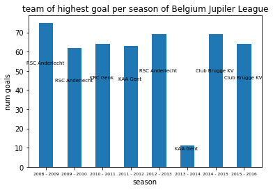

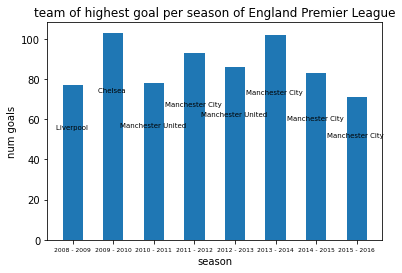

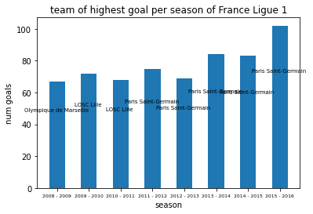

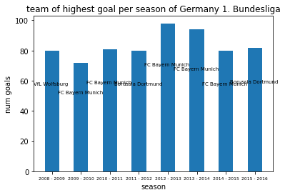

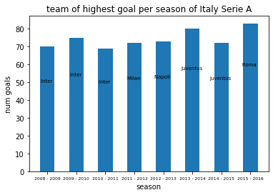

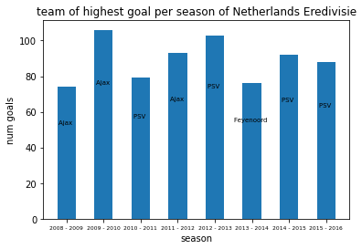

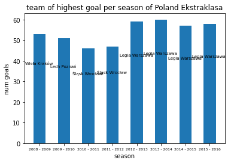

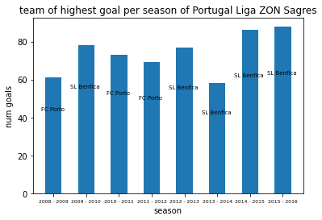

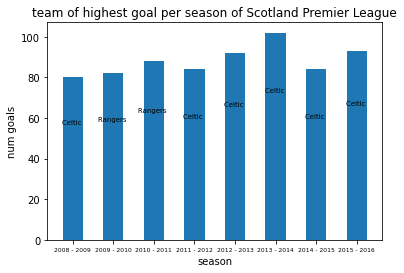

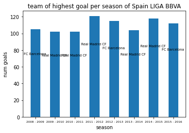

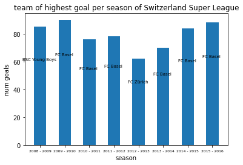

```python
%matplotlib inline

leagues = num_goal_highest.leagueName.unique()
count = 0
for league in leagues:
    new_df = num_goal_highest[num_goal_highest['leagueName'] == league]
    labels = new_df.season_start
    x = np.arange(len(labels))
    goals = new_df.total_num_goal
    width = 0.5
    fig, ax = plt.subplots()
    rects = ax.bar(x , goals, width)
    ax.set_ylabel('num goals')
    ax.set_xlabel('season')
    ax.set_title("team of highest goal per season of " + league)
    ax.set_xticks(x)
    ax.set_xticklabels(labels, fontsize=6)


    teams_label = new_df.team_name
    for rect in rects:
        team_name = teams_label[count].split("(")[0]
        height = rect.get_height() +1
        ax.text(rect.get_x() + width*0.5, 0.7*height, team_name,
                    ha='center', va='bottom', fontsize=7)
        count = count +1
    plt.show()
```

### 2. Which team won the most games per league and per year?

Very similarly to what we did for the previous question, we will first aggregate each teams wins.

```python
df = team_match[team_match['winner'] != 'Tie'] # find rows with winner is not equal to Tie

df = df[['leagueName', 'season_start', 'winner']]
df['season_start'] = df['season_start'].astype(int)
```

Below we can see the teams with the most wins for each leaque over the years that the data set covers.

```python
most_wins = df.groupby(['leagueName', 'season_start', 'winner'])['winner'].count().sort_values(ascending=False)
most_wins.head()
```

```
leagueName               season_start  winner
Italy Serie A            2013          Juventus (JUV)          33
Spain LIGA BBVA          2011          Real Madrid CF (REA)    32
                         2012          FC Barcelona (BAR)      32
Scotland Premier League  2013          Celtic (CEL)            31
Spain LIGA BBVA          2009          FC Barcelona (BAR)      31
Name: winner, dtype: int64
```

Now we will be dividing them again to find the teams with the most wins in each league over the years.

```python
leagues = []
seasons = []
teams = []
count_wins = []
for index, value in most_wins.items():
    leagues.append(index[0])
    season_full = str(index[1]) + " - " + str(index[1] + 1)
    seasons.append(season_full)
    teams.append(index[2])
    count_wins.append(value)
d = {'league':leagues,'season':seasons,'team_name':teams,'count_wins':count_wins}
most_wins = pd.DataFrame(d)
B = most_wins
```

```python
most_wins = most_wins.loc[most_wins.groupby(["league", "season"])["count_wins"].idxmax()]
most_wins.reset_index(drop=False, inplace=True)
most_wins.head(10)
```

|  | index | league | season | team_name | count_wins |
| --- | --- | --- | --- | --- | --- |
| 0 | 75 | Belgium Jupiler League | 2008 - 2009 | RSC Anderlecht (AND) | 24 |
| 1 | 117 | Belgium Jupiler League | 2009 - 2010 | RSC Anderlecht (AND) | 22 |
| 2 | 226 | Belgium Jupiler League | 2010 - 2011 | KRC Genk (GEN) | 19 |
| 3 | 177 | Belgium Jupiler League | 2011 - 2012 | RSC Anderlecht (AND) | 20 |
| 4 | 201 | Belgium Jupiler League | 2012 - 2013 | RSC Anderlecht (AND) | 20 |
| 5 | 1459 | Belgium Jupiler League | 2013 - 2014 | KV Oostende (OOS) | 4 |
| 6 | 309 | Belgium Jupiler League | 2014 - 2015 | Club Brugge KV (CLB) | 17 |
| 7 | 150 | Belgium Jupiler League | 2015 - 2016 | Club Brugge KV (CLB) | 21 |
| 8 | 28 | England Premier League | 2008 - 2009 | Manchester United (MUN) | 28 |
| 9 | 31 | England Premier League | 2009 - 2010 | Manchester United (MUN) | 27 |

Now we can produce visualizations of these win counts and see which teams held the most wins each season in each league.

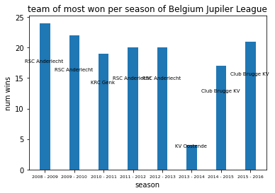

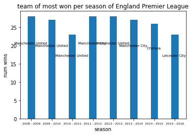

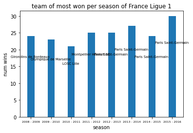

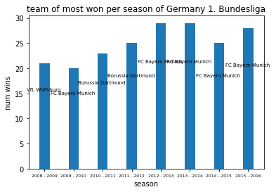

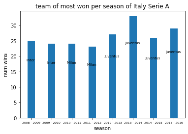

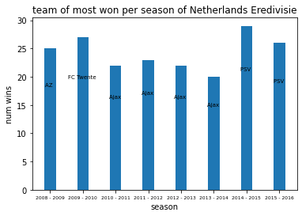

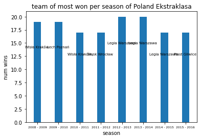

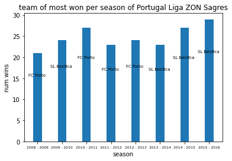

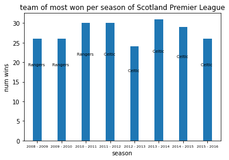

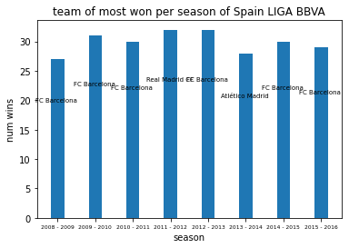

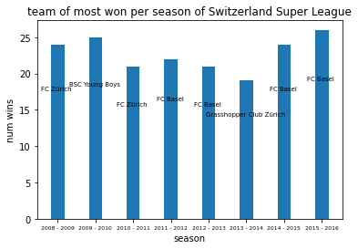

```python
leagues = most_wins.league.unique()
count = 0
for league in leagues:
    new_df = most_wins[most_wins['league'] == league]
    labels = new_df.season
    x = np.arange(len(labels))
    count_wins = new_df.count_wins
    width = 0.35
    fig, ax = plt.subplots()
    rects = ax.bar(x , count_wins, width)
    ax.set_ylabel('num wins')
    ax.set_xlabel('season')
    ax.set_title("team of most won per season of " + league)
    ax.set_xticks(x)
    ax.set_xticklabels(labels, fontsize=6)
    teams_label = new_df.team_name
    for rect in rects:
        team_name = teams_label[count].split("(")[0]
        height = rect.get_height() +1
        ax.text(rect.get_x()+ width*0.5, 0.7*height, team_name,
                    ha='center', va='bottom', fontsize=7)
        count = count +1
    plt.show()
```

With both these sets of data retieved, we can attempt some cross analysis and compare the goals scored by each team to the wins each team then holds.

```python
df = team_match[team_match['leagueName'] == 'Belgium Jupiler League']
df = df[df['season_start'] == '2013']
df.head()
```

|  | id | match_api_id | date | home_team | home_team_api_id | home_team_goal | away_team | away_team_api_id | away_team_goal | country_league_id | stage | season_start | season_end | countryName | leagueName | winner |
| --- | --- | --- | --- | --- | --- | --- | --- | --- | --- | --- | --- | --- | --- | --- | --- | --- |
| 784 | 1239 | 1677181 | 2014-04-05 | Lierse SK (LIE) | 9989 | 1 | KAA Gent (GEN) | 9991 | 0 | 1 | 2 | 2013 | 2014 | Belgium | Belgium Jupiler League | Lierse SK (LIE) |
| 791 | 1243 | 1677185 | 2014-04-19 | Waasland-Beveren (WAA) | 8475 | 2 | KAA Gent (GEN) | 9991 | 4 | 1 | 4 | 2013 | 2014 | Belgium | Belgium Jupiler League | KAA Gent (GEN) |
| 794 | 1246 | 1677188 | 2014-04-26 | KV Oostende (OOS) | 8573 | 1 | KAA Gent (GEN) | 9991 | 1 | 1 | 5 | 2013 | 2014 | Belgium | Belgium Jupiler League | Tie |
| 1418 | 1248 | 1677190 | 2014-05-03 | KAA Gent (GEN) | 9991 | 4 | Lierse SK (LIE) | 9989 | 0 | 1 | 6 | 2013 | 2014 | Belgium | Belgium Jupiler League | KAA Gent (GEN) |
| 1461 | 1237 | 1677179 | 2014-03-29 | Waasland-Beveren (WAA) | 8475 | 2 | Lierse SK (LIE) | 9989 | 0 | 1 | 1 | 2013 | 2014 | Belgium | Belgium Jupiler League | Waasland-Beveren (WAA) |

#### Comparing most goal team vs most won team per season and per league

```python
num_goal_highest.head()
```

|  | index | leagueName | season_start | team_name | total_num_goal |
| --- | --- | --- | --- | --- | --- |
| 0 | 11 | Belgium Jupiler League | 2008 - 2009 | RSC Anderlecht (AND) | 75 |
| 1 | 27 | Belgium Jupiler League | 2009 - 2010 | RSC Anderlecht (AND) | 62 |
| 2 | 37 | Belgium Jupiler League | 2010 - 2011 | KRC Genk (GEN) | 64 |
| 3 | 51 | Belgium Jupiler League | 2011 - 2012 | KAA Gent (GEN) | 63 |
| 4 | 75 | Belgium Jupiler League | 2012 - 2013 | RSC Anderlecht (AND) | 69 |

```python
most_wins.head()
```

|  | index | league | season | team_name | count_wins |
| --- | --- | --- | --- | --- | --- |
| 0 | 75 | Belgium Jupiler League | 2008 - 2009 | RSC Anderlecht (AND) | 24 |
| 1 | 117 | Belgium Jupiler League | 2009 - 2010 | RSC Anderlecht (AND) | 22 |
| 2 | 226 | Belgium Jupiler League | 2010 - 2011 | KRC Genk (GEN) | 19 |
| 3 | 177 | Belgium Jupiler League | 2011 - 2012 | RSC Anderlecht (AND) | 20 |
| 4 | 201 | Belgium Jupiler League | 2012 - 2013 | RSC Anderlecht (AND) | 20 |

```python
team_goal_won = pd.merge(num_goal_highest, most_wins,  how='left',
                         left_on=['leagueName','season_start'], right_on = ['league','season'])
team_goal_won = team_goal_won.drop(['index_x', 'league', 'season', 'index_y'], axis = 1)
team_goal_won = team_goal_won.rename(columns={"team_name_x": "team_highest_goal", "team_name_y": "team_most_won",
                                              "season_start": "season"})
team_goal_won.head()
```

|  | leagueName | season | team_highest_goal | total_num_goal | team_most_won | count_wins |
| --- | --- | --- | --- | --- | --- | --- |
| 0 | Belgium Jupiler League | 2008 - 2009 | RSC Anderlecht (AND) | 75 | RSC Anderlecht (AND) | 24 |
| 1 | Belgium Jupiler League | 2009 - 2010 | RSC Anderlecht (AND) | 62 | RSC Anderlecht (AND) | 22 |
| 2 | Belgium Jupiler League | 2010 - 2011 | KRC Genk (GEN) | 64 | KRC Genk (GEN) | 19 |
| 3 | Belgium Jupiler League | 2011 - 2012 | KAA Gent (GEN) | 63 | RSC Anderlecht (AND) | 20 |
| 4 | Belgium Jupiler League | 2012 - 2013 | RSC Anderlecht (AND) | 69 | RSC Anderlecht (AND) | 20 |

```python
goal_won_same = team_goal_won[team_goal_won['team_highest_goal'] == team_goal_won['team_most_won']]
```

```python
percent = goal_won_same.shape[0] / team_goal_won.shape[0]
percent * 100
```

```
63.63636363636363
```

From this analysis, we find that the team with the highest goals won the most games in a season roughly 64%.

We then can create a table with total goal number and total win count together for the best team per season and per league.

```python
# A with the copy of the number of goals table from earlier
for index, row in A.iterrows():
    A.iloc[index, 1] = str(A.iloc[index, 1]) + " - " + str(A.iloc[index, 1] + 1)
A.head()
```

|  | leagueName | season_start | away_team | home_team_goal | away_team_goal | total_num_goal |
| --- | --- | --- | --- | --- | --- | --- |
| 0 | Belgium Jupiler League | 2008 - 2009 | Beerschot AC (BAC) | 32 | 12 | 44 |
| 1 | Belgium Jupiler League | 2008 - 2009 | Club Brugge KV (CLB) | 37 | 22 | 59 |
| 2 | Belgium Jupiler League | 2008 - 2009 | FCV Dender EH (DEN) | 21 | 23 | 44 |
| 3 | Belgium Jupiler League | 2008 - 2009 | KAA Gent (GEN) | 31 | 36 | 67 |
| 4 | Belgium Jupiler League | 2008 - 2009 | KRC Genk (GEN) | 23 | 25 | 48 |

```python
A = A.rename(columns={"away_team": "team_name"})
A.drop(columns = ['home_team_goal', 'away_team_goal'], axis = 1, inplace = True)
```

```python
A.head()
```

|  | leagueName | season_start | team_name | total_num_goal |
| --- | --- | --- | --- | --- |
| 0 | Belgium Jupiler League | 2008 - 2009 | Beerschot AC (BAC) | 44 |
| 1 | Belgium Jupiler League | 2008 - 2009 | Club Brugge KV (CLB) | 59 |
| 2 | Belgium Jupiler League | 2008 - 2009 | FCV Dender EH (DEN) | 44 |
| 3 | Belgium Jupiler League | 2008 - 2009 | KAA Gent (GEN) | 67 |
| 4 | Belgium Jupiler League | 2008 - 2009 | KRC Genk (GEN) | 48 |

```python
B.head()
```

|  | league | season | team_name | count_wins |
| --- | --- | --- | --- | --- |
| 0 | Italy Serie A | 2013 - 2014 | Juventus (JUV) | 33 |
| 1 | Spain LIGA BBVA | 2011 - 2012 | Real Madrid CF (REA) | 32 |
| 2 | Spain LIGA BBVA | 2012 - 2013 | FC Barcelona (BAR) | 32 |
| 3 | Scotland Premier League | 2013 - 2014 | Celtic (CEL) | 31 |
| 4 | Spain LIGA BBVA | 2009 - 2010 | FC Barcelona (BAR) | 31 |

```python
team_goal_won_total = pd.merge(A, B,  how='left',
                         left_on=['leagueName','season_start', 'team_name'], right_on = ['league','season', 'team_name'])
team_goal_won_total = team_goal_won_total.drop(['league', 'season'], axis = 1)
team_goal_won_total = team_goal_won_total.rename(columns={"season_start": "season"})
team_goal_won_total.head()
```

|  | leagueName | season | team_name | total_num_goal | count_wins |
| --- | --- | --- | --- | --- | --- |
| 0 | Belgium Jupiler League | 2008 - 2009 | Beerschot AC (BAC) | 44 | 11 |
| 1 | Belgium Jupiler League | 2008 - 2009 | Club Brugge KV (CLB) | 59 | 18 |
| 2 | Belgium Jupiler League | 2008 - 2009 | FCV Dender EH (DEN) | 44 | 9 |
| 3 | Belgium Jupiler League | 2008 - 2009 | KAA Gent (GEN) | 67 | 17 |
| 4 | Belgium Jupiler League | 2008 - 2009 | KRC Genk (GEN) | 48 | 15 |